# DA2 Homework Assignment 01 - Linear Regression Analysis

Gaire Ananta Prasad M24W0272

```r
# Load the dataset
advertising_data <- read.csv("/Users/gaire/Documents/Assignement 1/Advertising.csv")
head(advertising_data)
```

```
##   X    TV Radio Newspaper Sales
## 1 1 230.1  37.8      69.2  22.1
## 2 2  44.5  39.3      45.1  10.4
## 3 3  17.2  45.9      69.3   9.3
## 4 4 151.5  41.3      58.5  18.5
## 5 5 180.8  10.8      58.4  12.9
## 6 6   8.7  48.9      75.0   7.2
```

M24W0272 Gaire Ananta Prasad Our goal is to investigate the effect that advertising costs through TV, Radio and Newspaper platforms have on product sales. Through the statistical analysis method Linear Regression we identify and understand the connection between these variables.

```r
str(advertising_data)
```

```
## 'data.frame':    200 obs. of  5 variables:
##  $ X        : int  1 2 3 4 5 6 7 8 9 10 ...
##  $ TV       : num  230.1 44.5 17.2 151.5 180.8 ...
##  $ Radio    : num  37.8 39.3 45.9 41.3 10.8 48.9 32.8 19.6 2.1 2.6 ...
##  $ Newspaper: num  69.2 45.1 69.3 58.5 58.4 75 23.5 11.6 1 21.2 ...
##  $ Sales    : num  22.1 10.4 9.3 18.5 12.9 7.2 11.8 13.2 4.8 10.6 ...
```

```r
summary(advertising_data)
```

```
##        X                TV             Radio          Newspaper
##  Min.   :  1.00   Min.   :  0.70   Min.   : 0.000   Min.   :  0.30
##  1st Qu.: 50.75   1st Qu.: 74.38   1st Qu.: 9.975   1st Qu.: 12.75
##  Median :100.50   Median :149.75   Median :22.900   Median : 25.75
##  Mean   :100.50   Mean   :147.04   Mean   :23.264   Mean   : 30.55
##  3rd Qu.:150.25   3rd Qu.:218.82   3rd Qu.:36.525   3rd Qu.: 45.10
##  Max.   :200.00   Max.   :296.40   Max.   :49.600   Max.   :114.00
##      Sales
##  Min.   : 1.60
##  1st Qu.:10.38
##  Median :12.90
##  Mean   :14.02
##  3rd Qu.:17.40
##  Max.   :27.00
```

```r
# Linear regression for TV vs. Sales
model_tv <- lm(Sales ~ TV, data = advertising_data)
summary(model_tv)
```

```
##
## Call:
## lm(formula = Sales ~ TV, data = advertising_data)
##
## Residuals:
##     Min      1Q  Median      3Q     Max
## -8.3860 -1.9545 -0.1913  2.0671  7.2124
##
## Coefficients:
##             Estimate Std. Error t value Pr(>|t|)
## (Intercept) 7.032594   0.457843   15.36   <2e-16 ***
## TV          0.047537   0.002691   17.67   <2e-16 ***
## ---
## Signif. codes:  0 '***' 0.001 '**' 0.01 '*' 0.05 '.' 0.1 ' ' 1
##
## Residual standard error: 3.259 on 198 degrees of freedom
## Multiple R-squared:  0.6119, Adjusted R-squared:  0.6099
## F-statistic: 312.1 on 1 and 198 DF,  p-value: < 2.2e-16
```

Gaire Ananta Prasad M24W0272 The basic linear regression shows that advertising on television creates both a robust and favorable impact on sales levels. The value of 0.0475 found in the TV variable shows that sales grow about 47.5 units in response to each additional $1,000 budget dedicated to television advertising. The statistical significance of this result becomes evident because the p-value reaches below two inverse octillion (2e-16). The analysis indicates that TV advertising accounts for 61% of the total factors affecting sales variation. TV advertising establishes itself as a powerful tool that drives sales performance so it becomes a vital element for company success prediction.

```r
model <- lm(Sales ~ TV, data = advertising_data)
```

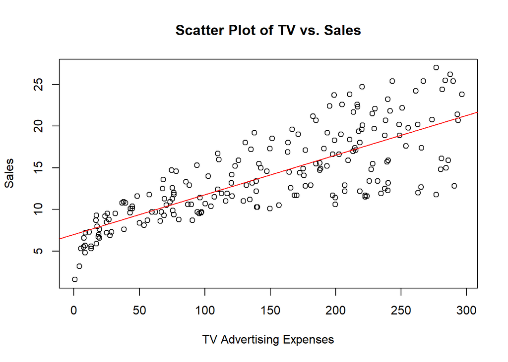

```r
plot(advertising_data$TV, advertising_data$Sales, xlab = "TV Advertising Expenses", ylab = "Sales", main = "Scatter Plot of TV vs. Sales")
abline(model, col = "red")
```

M24W0272 Gaire Ananta Prasad A plot depicting TV advertising efforts against sales demonstrates an evident positive linear relationship where greater TV advertisement investment leads to increased product sales. The plot displays an outline regression line determined by our model which serves to fit the data best. The data distribution pattern in the visual representation demonstrates how well the model has been fitted because most of the points cluster near the drawn line. Analysis through the chart substantiates our discovery that product sales grow based on increased TV advertising investments.

```r
predicted_sales <- predict(model, newdata = data.frame(TV = advertising_data$TV))
residuals <- advertising_data$Sales - predicted_sales
residuals
```

[output not shown]

[output cut: 13 more lines]

[output not shown]

```r
mse <- mean(residuals^2)
mse
```

```
## [1] 10.51265
```

#Linear regression for Radio

```r
model_radio <- lm(Sales ~ Radio, data = advertising_data)
summary(model_radio)
```

```
##
## Call:
## lm(formula = Sales ~ Radio, data = advertising_data)
##
## Residuals:
##      Min       1Q   Median       3Q      Max
## -15.7305  -2.1324   0.7707   2.7775   8.1810
##
## Coefficients:
##             Estimate Std. Error t value Pr(>|t|)
## (Intercept)  9.31164    0.56290  16.542   <2e-16 ***
## Radio        0.20250    0.02041   9.921   <2e-16 ***
## ---
## Signif. codes:  0 '***' 0.001 '**' 0.01 '*' 0.05 '.' 0.1 ' ' 1
##
## Residual standard error: 4.275 on 198 degrees of freedom
## Multiple R-squared:  0.332,  Adjusted R-squared:  0.3287
## F-statistic: 98.42 on 1 and 198 DF,  p-value: < 2.2e-16
```

Gaire Ananta Prasad M24W0272 This model evaluates the impact of Radio advertising on sales. The coefficient for Radio is 0.2025, which suggests that for each additional $1,000 spent on radio ads, sales are projected to increase by approximately 202.5 units.

With a p-value less than 2e-16, the relationship is highly statistically significant. The R-squared value of 0.332 indicates that about 33% of the variation in sales can be explained by radio advertising alone.

While this is lower than the explanatory power of TV advertising, Radio still plays a significant role and could be a cost-effective channel for boosting sales.

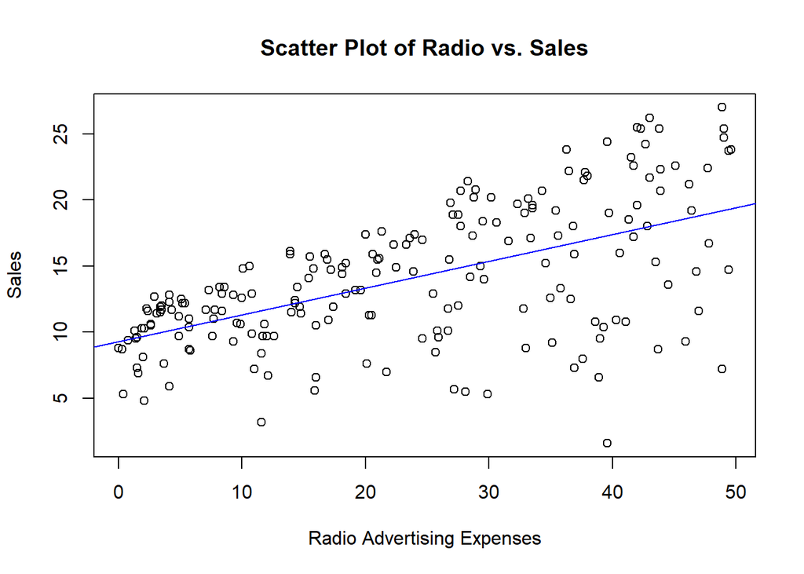

```r
radio_model <- lm(Sales ~ Radio, data = advertising_data)
plot(advertising_data$Radio, advertising_data$Sales,
xlab = "Radio Advertising Expenses",
ylab = "Sales",
main = "Scatter Plot of Radio vs. Sales")
abline(radio_model, col = "blue")
```

```r
predicted_sales <- predict(model, newdata = data.frame(
TV = advertising_data$TV,
Radio = advertising_data$Radio,
Newspaper = advertising_data$Newspaper
))
residuals <- advertising_data$Sales - predicted_sales
residuals
```

[output not shown]

[output cut: 13 more lines]

[output not shown]

#Linear regression for Newspaper

```r
model_newspaper <- lm(Sales ~ Newspaper, data = advertising_data)
summary(model_newspaper)
```

```
##
## Call:
## lm(formula = Sales ~ Newspaper, data = advertising_data)
##
## Residuals:
##      Min       1Q   Median       3Q      Max
## -11.2272  -3.3873  -0.8392   3.5059  12.7751
##
## Coefficients:
##             Estimate Std. Error t value Pr(>|t|)
## (Intercept) 12.35141    0.62142   19.88  < 2e-16 ***
## Newspaper    0.05469    0.01658    3.30  0.00115 **
## ---
## Signif. codes:  0 '***' 0.001 '**' 0.01 '*' 0.05 '.' 0.1 ' ' 1
##
## Residual standard error: 5.092 on 198 degrees of freedom
## Multiple R-squared:  0.05212,    Adjusted R-squared:  0.04733
## F-statistic: 10.89 on 1 and 198 DF,  p-value: 0.001148
```

M24W0272 Gaire Ananta Prasad This model analyzes the impact of Newspaper advertising on sales. The coefficient of 0.0547 indicates a weak positive relationship — sales tend to increase slightly as newspaper ad spending goes up.

The R-squared value is 0.052, meaning that only 5.2% of the variation in sales can be explained by newspaper advertising, pointing to a relatively low predictive power for this variable.

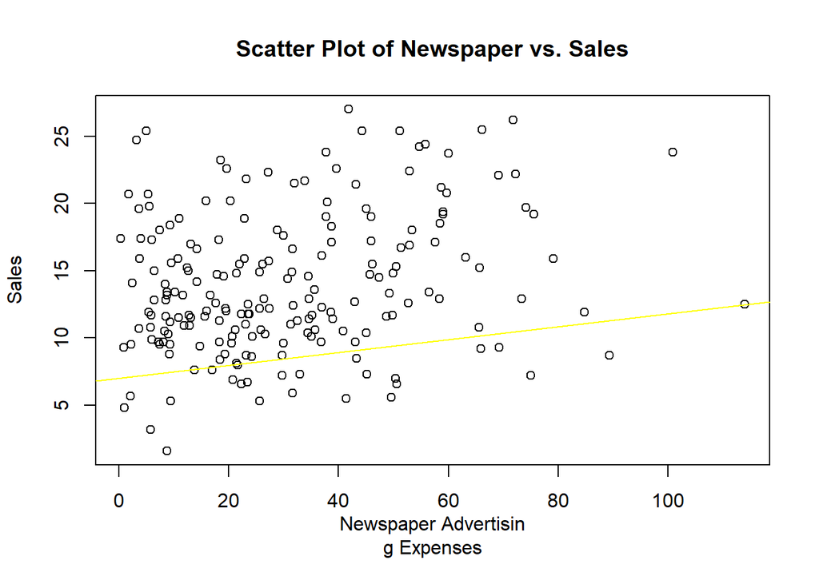

```r
plot(advertising_data$Newspaper, advertising_data$Sales, xlab = "Newspaper Advertisin
g Expenses", ylab = "Sales", main = "Scatter Plot of Newspaper vs. Sales")
abline(model, col = "yellow")
```

M24W0272 Gaire Ananta Prasad The linear regression results suggest that Newspaper advertising has a minor yet statistically meaningful impact on sales. For each additional unit spent on newspaper ads, sales are expected to rise by approximately 0.055 units.

Despite this, the model accounts for only around 5% of the variation in sales, implying that newspaper advertising on its own is a weak predictor of sales outcomes.

Overall, while there is some positive effect, Newspaper ads appear less effective when compared to more influential channels like TV or Radio.

```r
predicted_sales <- predict(model, newdata = data.frame(
TV = advertising_data$TV,
Radio = advertising_data$Radio,
Newspaper = advertising_data$Newspaper
))
residuals <- advertising_data$Sales - predicted_sales
residuals
```

[output not shown]

[output cut: 13 more lines]

[output not shown]

Despite this, the low R-squared value of 0.04733 indicates that Newspaper advertising has limited explanatory power — it accounts for only a small fraction of the variation in sales. This reinforces the idea that newspaper ads alone are not a reliable predictor of sales performance.